# BIO-463: Single-cell RNA-sequencing data (I)

Raphaëlle Luisier and Lisa Fournier, Idiap Research Institute

April 2024

# 1 Introduction to the data-set

In this tutorial, we will analyze single-cell RNA sequencing data from [Ho et. al, Genome Research, 2018](https://www.ncbi.nlm.nih.gov/pubmed/30061114). They are derived from 451Lu melanoma cell line in two different conditions: 1) parental (untreated) and 2) resistant (treated for 6 weeks with BRAF inhibitors and yet proliferating hence called resistant):

[figure not shown]

**Schematic depicting the experimental protocol.**

Importantly the differences between these two cell populations are 1) the exposure to treatment (none versus chronic); 2) the resistance that emerges from the treatment. Hence these two variables (treatment and resistance) are confounded by the experimental set-up. This tutorial is built on the [Seurat package](https://satijalab.org/seurat/); you can refer to their vignettes for more details about the functions.

## 1.1 Load the data

```r
load("C:/Users/norar/OneDrive/Documentos/EPFL/Genomics and bioinformatics/Week 9/11032235/scRNA_data_melanoma.RData")
#Data:
# expression_matrix       : 19386 x 8574 sparse Matrix of class "dgTMatrix" in triplet form https://www.rdocumentation.org/packages/Matrix/versions/1.6-5/topics/dgTMatrix-class
# cell_metadata           : matrix of dimension n_cells X 2; col1=uniqueID of the cell; col2=variable ()
# gene_metadata           : matrix of dimension n_genes X 1; simply the gene symbols of the rows of the expression matrices
mycols <- c("#6699FF", "#CC33CC")
```

## 1.2 Inspect the data

Let’s check how many genes we have quantified and across how many cells:

```r
str(expression_matrix)
```

```
## Formal class 'dgTMatrix' [package "Matrix"] with 6 slots
##   ..@ i       : int [1:29660859] 19 28 52 57 114 120 133 134 135 136 ...
##   ..@ j       : int [1:29660859] 0 0 0 0 0 0 0 0 0 0 ...
##   ..@ Dim     : int [1:2] 19386 8574
##   ..@ Dimnames:List of 2
##   .. ..$ : chr [1:19386] "OR4F5" "OR4F29" "AL645608.2" "SAMD11" ...
##   .. ..$ : chr [1:8574] "AAACCTGAGCGTTGCC" "AAACCTGCAAACTGTC" "AAACCTGCAGCGTCCA" "AAACCTGCATATGAGA" ...
##   ..@ x       : num [1:29660859] 1 2 1 1 7 1 1 5 1 1 ...
##   ..@ factors : list()
```

```r
print(paste("n_genes=",dim(expression_matrix)[1]))
```

```
## [1] "n_genes= 19386"
```

```r
print(paste("n_cells=",dim(expression_matrix)[2]))
```

```
## [1] "n_cells= 8574"
```

Let’s look at how many cells are parental versus resistant:

```r
print(table(cell_metadata[,2]))
```

```
##
##  parental resistant
##      4452      4122
```

## 1.3 Create a Seurat object

Let’s now create a Seurat object. Please note that we do not filter out genes according to a pre-determined number of reads as we are going to automatically identify the correct number of reliable genes as previously performed in bulk gene expression.

```r
# Create the Seurat
GE <- CreateSeuratObject(counts = expression_matrix, meta.data = as.data.frame(cell_metadata), min.cells = 5, min.features = 0)
# Explore merged metadata
#View(GE@meta.data)
```

# 2 Quality control and filtering of low-quality cells

Quality control (QC) is a critical step in single-cell RNA-seq (scRNA-seq) data analysis. Low-quality cells are removed from the analysis during the QC process to avoid misinterpretation of the data. Seurat object has two features:

- **nFeature_RNA** is the number of genes detected in each cell; low nFeature_RNA for a cell indicates that it may be dead/dying or an empty droplet.
- **nCount_RNA** is the total number of molecules (UMI) detected within a cell. Can be high yet all coming from the same gene.

High nCount_RNA and/or nFeature_RNA indicates that the a cell may in fact be a doublet (or multiplet). We can calculate two additional metrics for QC:

- **number of genes detected per UMI** which gives an idea of the complexity of the dataset i.e. the more genes detected per UMI, the more complex the data.
- **mitochondrial ratio** which gives a percentage of cell reads originating from the mitochondrial genes.

The QC process usually involves applying **user-defined thresholds** for different metrics computed for each individual cell to filter out doublets and ‘low-quality’ cells [Luecken et al, 2019](https://pubmed.ncbi.nlm.nih.gov/31217225/). Cell filtering is performed according to several criteria that are going to be used sequentially.

- UMI counts (nCount_RNA) per cell
- Genes (nFeature_RNA) detected per cell
- UMIs vs. genes detected
- Mitochondrial counts ratio
- Complexity of the library

Cells that are poor quality are likely to have low genes and UMIs per cell, as well as high mitochondrial counts ratio. Good cells will generally exhibit both higher number of genes per cell and higher numbers of UMIs. In single-cell RNA sequencing experiments, doublets are generated from two cells. They typically arise due to errors in cell sorting or capture, especially in droplet-based protocols involving thousands of cells.

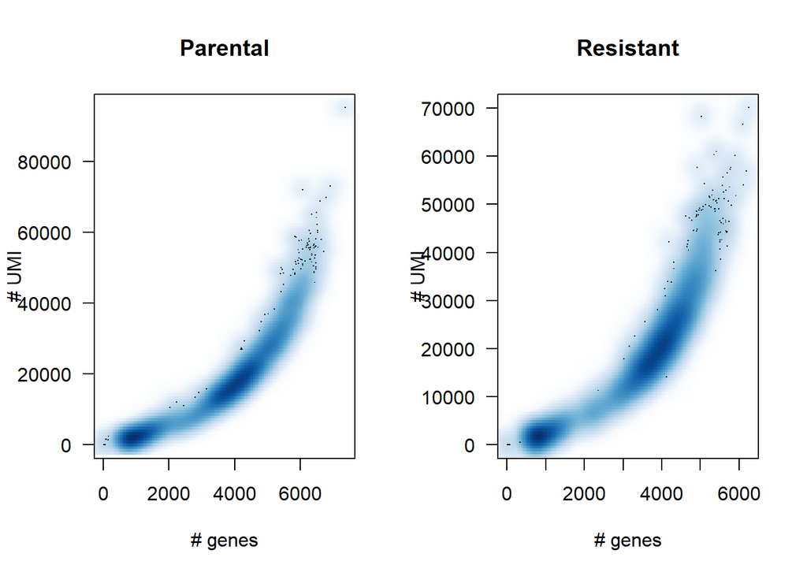

```r
layout(matrix(ncol=2,nrow=1,c(1:2),byrow = TRUE))
# Add number of genes per UMI for each cell to metadata
GE$log10GenesPerUMI <- log10(GE$nFeature_RNA) / log10(GE$nCount_RNA)
#another notation: GE[["log10GenesPerUMI"]]        <- log10(GE$nFeature_RNA) / log10(GE$nCount_RNA)
# Compute percent mito ratio
GE$mitoRatio        <- PercentageFeatureSet(object = GE, pattern = "^MT-")/100
#another notation: GE[["mitoRatio"]]        <- PercentageFeatureSet(object = GE, pattern = "^MT-")/100


#Create subsets to facilitate the analysis
GE_parental         <- subset(GE, subset = treatment == "parental")
GE_resistant        <- subset(GE, subset = treatment == "resistant")

#Compare #genes versus UMI
smoothScatter(GE_parental$nFeature_RNA,GE_parental$nCount_RNA,las=1,main="Parental",xlab="# genes",ylab="# UMI")
smoothScatter(GE_resistant$nFeature_RNA,GE_resistant$nCount_RNA,las=1,main="Resistant",xlab="# genes",ylab="# UMI")
```

## 2.1 UMI counts per cell

The UMI counts per cell should generally be above 500, that is the low end of what we expect. If UMI counts are between 500-1000 counts, it is usable but the cells probably should have been sequenced more deeply.

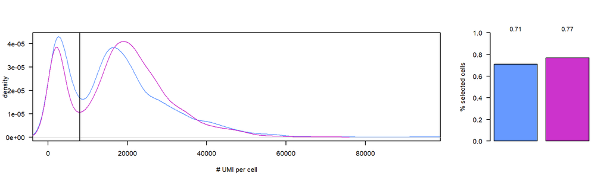

```r
layout(matrix(ncol=4,nrow=1,c(1,1,1,2),byrow = TRUE))
myUMI<- list(GE_parental$nCount_RNA,GE_resistant$nCount_RNA)
multidensity(myUMI,las=1,xlab="# UMI per cell",ylab="density",col=mycols,main="",leg=FALSE)
abline(v=8000)
myvals=unlist(lapply(myUMI,function(Z)return(sum(Z>8000)/length(Z))))
mp<- barplot(myvals,las=1,col=mycols,ylab="% selected cells",ylim=c(0,1))
mtext(side=3,line=0,text=round(myvals,digit=2),cex=0.6,at=mp)
```

```r
sel_UMI<- GE$nCount_RNA>8000
```

## 2.2 Genes detected per cell

For high quality data, the proportional histogram should contain a single large peak that represents cells that were encapsulated. If we see a small shoulder to the right of the major peak or a bimodal distribution of the cells, that can indicate a couple of things:

- It might be that there are a set of cells that failed for some reason.
- It could also be that there are biologically different types of cells (i.e. quiescent cell populations, less complex cells of interest), and/or one type is much smaller than the other (i.e. cells with high counts may be cells that are larger in size).

```r
# 1 Fit bimodal distribution
bimdens              <- mclust::densityMclust(data=GE$nFeature_RNA,G=2,plot=FALSE)
```

```
## fitting ...
##   |                                                                                                                                                           |                                                                                                                                          …
```

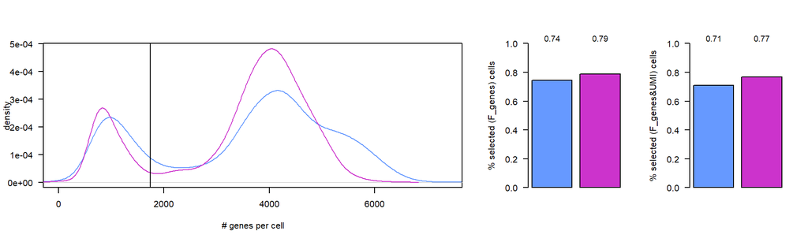

```r
# 2. Identify limit that discriminate foreground from background
lim                  <- qnorm(0.99,mean=bimdens$parameters$mean[1],sd=sqrt(bimdens$parameters$variance$sigmasq[1]))
# Visualise those values
layout(matrix(ncol=5,nrow=1,c(1,1,1,2,3),byrow = TRUE))
myGenes<- list(GE_parental$nFeature_RNA,GE_resistant$nFeature_RNA)
multidensity(myGenes,las=1,xlab="# genes per cell",ylab="density",col=mycols,main="",leg=FALSE)
abline(v=lim)
myvals=unlist(lapply(myGenes,function(Z)return(sum(Z>2000)/length(Z))))
mp<- barplot(myvals,las=1,col=mycols,ylab="% selected (F_genes) cells",ylim=c(0,1))
mtext(side=3,line=0,text=round(myvals,digit=2),cex=0.6,at=mp)


sel_Genes<- GE$nFeature_RNA>2000
myvals=c(sum(sel_Genes&sel_UMI&GE$treatment=="parental")/sum(GE$treatment=="parental"),
  sum(sel_Genes&sel_UMI&GE$treatment=="resistant")/sum(GE$treatment=="resistant"))
mp<-barplot(myvals,las=1,col=mycols,ylab="% selected (F_genes&UMI) cells",ylim=c(0,1))
mtext(side=3,line=0,text=round(myvals,digit=2),cex=0.6,at=mp)
```

## 2.3 Mitochondrial genes

This metric can identify whether there is a large amount of mitochondrial contamination from dead or dying cells. Early publications in the field established a threshold of 5% and since then, it has been used as a default in several software packages for scRNA-seq data analysis, and adopted as a standard in many scRNA-seq studies. However, the validity of using a uniform threshold across different species, single-cell technologies, tissues and cell types has not been adequately assessed [Osorio et al. (2021)](https://www.ncbi.nlm.nih.gov/pmc/articles/PMC8599307/). Other defined poor quality samples for mitochondrial counts as cells **which surpass the 0.2 mitochondrial ratio mark**.[Source: hbctraining.github.io](https://hbctraining.github.io/scRNA-seq/lessons/04_SC_quality_control.html)

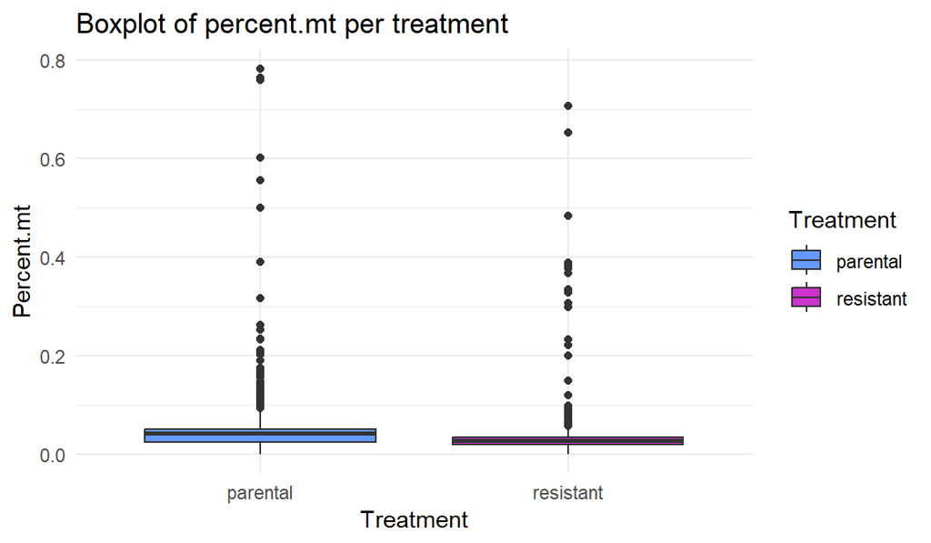

```r
par(mfrow=c(1,1),mar=c(10,20,10,5))

# Create a data frame with the treatment and percent.mt values
data_mt <- data.frame(Treatment = GE@meta.data$treatment, PercentMT = GE@meta.data$mitoRatio)

# Create the boxplot
ggplot(data_mt, aes(x = Treatment, y = PercentMT, fill = Treatment)) +
  geom_boxplot() + scale_fill_manual(values = mycols) +
  theme_minimal() +
  labs(title = "Boxplot of percent.mt per treatment", x = "Treatment", y = "Percent.mt")
```

We can now test what would be the optimal threshold values for each individual samples by using the IQR values (identification of outliers).

```r
# Compute the upper quartile and the interquartile range
Q3_par  <- quantile(data_mt[which(data_mt$Treatment=='parental'),]$PercentMT, 0.75)
IQR_par <- IQR(data_mt[which(data_mt$Treatment=='parental'),]$PercentMT)

Q3_res <- quantile(data_mt[which(data_mt$Treatment=='resistant'),]$PercentMT, 0.75)
IQR_res <- IQR(data_mt[which(data_mt$Treatment=='resistant'),]$PercentMT)

# Define the upper limit for outliers
upper_limit_par <- Q3_par + 1.5 * IQR_par
upper_limit_res <- Q3_res + 1.5 * IQR_res
```

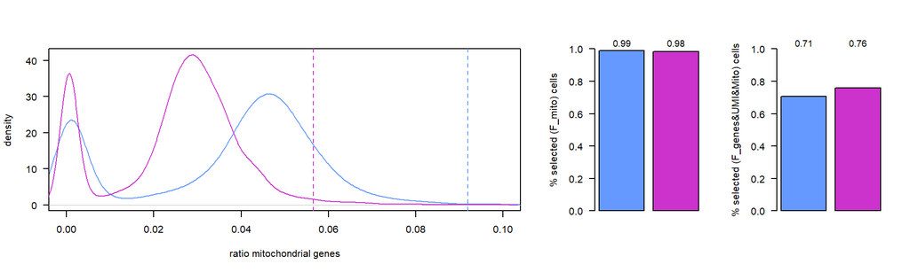

```r
layout(matrix(ncol=5,nrow=1,c(1,1,1,2,3),byrow = TRUE))
myGenes<- list(GE_parental$mitoRatio,GE_resistant$mitoRatio)
multidensity(myGenes,las=1,xlab="ratio mitochondrial genes",ylab="density",col=mycols,main="",leg=TRUE,xlim=c(0,0.1))
abline(v=c(upper_limit_par,upper_limit_res),col=mycols,lty=2)
myLims=c(upper_limit_par,upper_limit_res)
myvals=unlist(lapply(c(1,2),function(IX)return(sum(myGenes[[IX]]<myLims[IX])/length(myGenes[[IX]]))))
mp<- barplot(myvals,las=1,col=mycols,ylab="% selected (F_mito) cells",ylim=c(0,1))
mtext(side=3,line=0,text=round(myvals,digit=2),cex=0.6,at=mp)

sel_Mito<- GE$mitoRatio<myLims[1]&GE$treatment=="parental"|GE$mitoRatio<myLims[2]&GE$treatment=="resistant"
myvals<- c(sum(sel_Genes&sel_UMI&sel_Mito&GE$treatment=="parental")/sum(GE$treatment=="parental"),
  sum(sel_Genes&sel_UMI&sel_Mito&GE$treatment=="resistant")/sum(GE$treatment=="resistant"))
mp<-barplot(myvals,las=1,col=mycols,ylab="% selected (F_genes&UMI&Mito) cells",ylim=c(0,1))
mtext(side=3,line=0,text=round(myvals,digit=2),cex=0.6,at=mp)
```

## 2.4 Complexity

The number of genes detected per UMI gives an idea of the complexity of the data-set: the more genes detected per UMI, the more complex the data. Sometimes we can detect contamination with low complexity cell types like red blood cells via this metric. Generally, we expect the novelty score to be above 0.80.

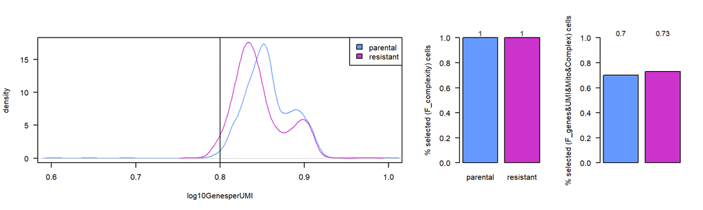

```r
layout(matrix(ncol=5,nrow=1,c(1,1,1,2,3),byrow = TRUE))
myGenes<- list(GE_parental$log10GenesPerUMI,GE_resistant$log10GenesPerUMI)
names(myGenes) <- c("parental","resistant")
multidensity(myGenes,las=1,xlab="log10GenesperUMI",ylab="density",col=mycols,main="",xlim=c(0.6,1.0))
abline(v=0.8)
myvals=unlist(lapply(myGenes,function(Z)return(sum(Z>0.08)/length(Z))))
mp<- barplot(myvals,las=1,col=mycols,ylab="% selected (F_complexity) cells",ylim=c(0,1))
mtext(side=3,line=0,text=round(myvals,digit=2),cex=0.6,at=mp)

sel_complex<- GE$log10GenesPerUMI>0.8
myvals<- c(sum(sel_Genes&sel_UMI&sel_Mito&sel_complex&GE$treatment=="parental")/sum(GE$treatment=="parental"),
  sum(sel_Genes&sel_UMI&sel_Mito&sel_complex&GE$treatment=="resistant")/sum(GE$treatment=="resistant"))
mp<-barplot(myvals,las=1,col=mycols,ylab="% selected (F_genes&UMI&Mito&Complex) cells",ylim=c(0,1))
mtext(side=3,line=0,text=round(myvals,digit=2),cex=0.6,at=mp)
```

## 2.5 Relation between the different metrics

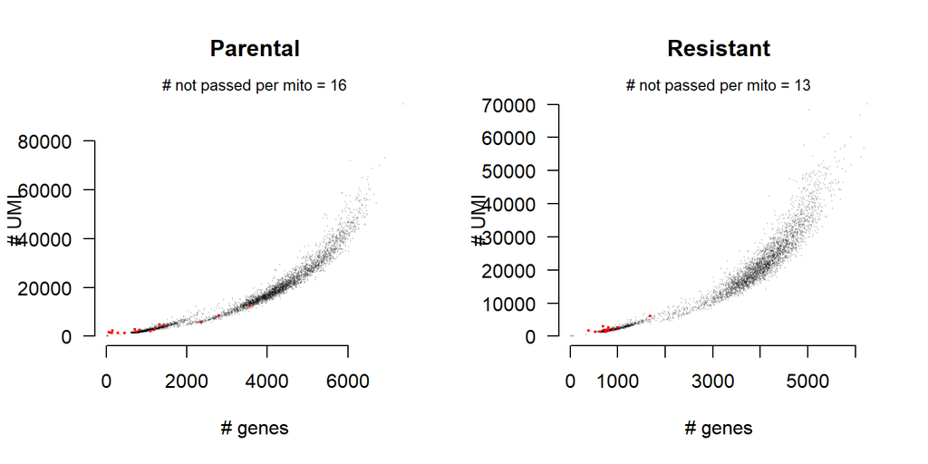

```r
layout(matrix(ncol=2,nrow=1,c(1:2),byrow = TRUE))
GE_parental  <- subset(GE, subset = treatment == "parental")
GE_resistant <- subset(GE, subset = treatment == "resistant")

plot(GE_parental$nFeature_RNA,GE_parental$nCount_RNA,las=1,main="Parental",xlab="# genes",ylab="# UMI",pch=19,cex=0.1,col=rgb(0,0,0,0.1),frame=FALSE)
points(GE_parental$nFeature_RNA[GE_parental$mitoRatio>0.2],GE_parental$nCount_RNA[GE_parental$mitoRatio>0.2],col="red",pch=19,cex=0.3)
mtext(side=3,line=0,text=paste("# not passed per mito =",sum(GE_parental$mitoRatio>0.2)),cex=0.8)

plot(GE_resistant$nFeature_RNA,GE_resistant$nCount_RNA,las=1,main="Resistant",xlab="# genes",ylab="# UMI",pch=19,cex=0.1,col=rgb(0,0,0,0.1),frame=FALSE)
points(GE_resistant$nFeature_RNA[GE_resistant$mitoRatio>0.2],GE_resistant$nCount_RNA[GE_resistant$mitoRatio>0.2],col="red",pch=19,cex=0.3)
mtext(side=3,line=0,text=paste("# not passed per mito =",sum(GE_resistant$mitoRatio>0.2)),cex=0.8)
```

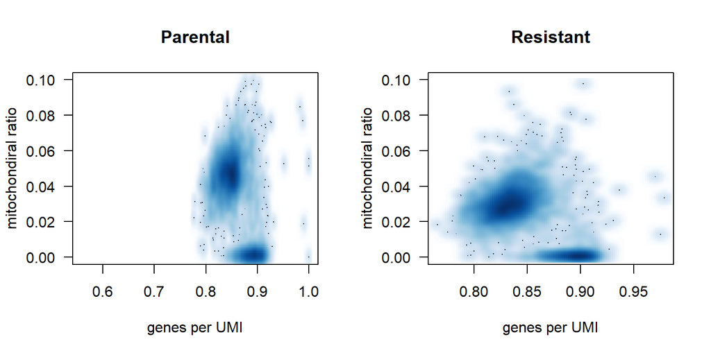

```r
layout(matrix(ncol=2,nrow=1,c(1:2),byrow = TRUE))

smoothScatter(GE_parental$log10GenesPerUMI,GE_parental$mitoRatio,las=1,main="Parental",xlab="genes per UMI",ylab="mitochondiral ratio",ylim=c(0,0.1))
smoothScatter(GE_resistant$log10GenesPerUMI,GE_resistant$mitoRatio,las=1,main="Resistant",xlab="genes per UMI",ylab="mitochondiral ratio",ylim=c(0,0.1))
```

## 2.6 Filtering

Considering any of the QC metrics in isolation can lead to misinterpretation of cellular signals. For example, cells with a comparatively high fraction of mitochondrial counts may be involved in respiratory processes and may be cells that you would like to keep. Likewise, other metrics can have other biological interpretations. Thus, always consider the joint effects of these metrics when setting thresholds and set them to be as permissive as possible to avoid filtering out viable cell populations unintentionally.

In summary here we are going to use the following thresholds that need to be carefully considered for each experiment/data-set:

- nGene > 1745.1675057
- nUMI > 500
- mitoRatio < 0.0919709 for parental and 0.0564841 for resistant
- log10GenesPerUMI > 0.8

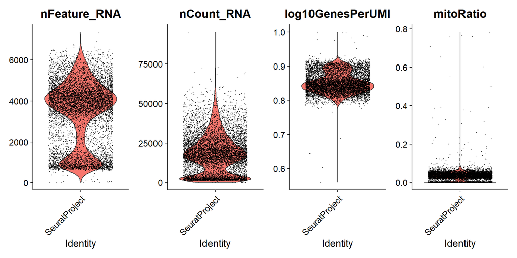

```r
layout(matrix(ncol=1,nrow=1,1,byrow = TRUE))
VlnPlot(GE, features = c("nFeature_RNA", "nCount_RNA", "log10GenesPerUMI","mitoRatio"), ncol = 4)
```

The following plot shows the distribution of the metrics **prior filtering**:

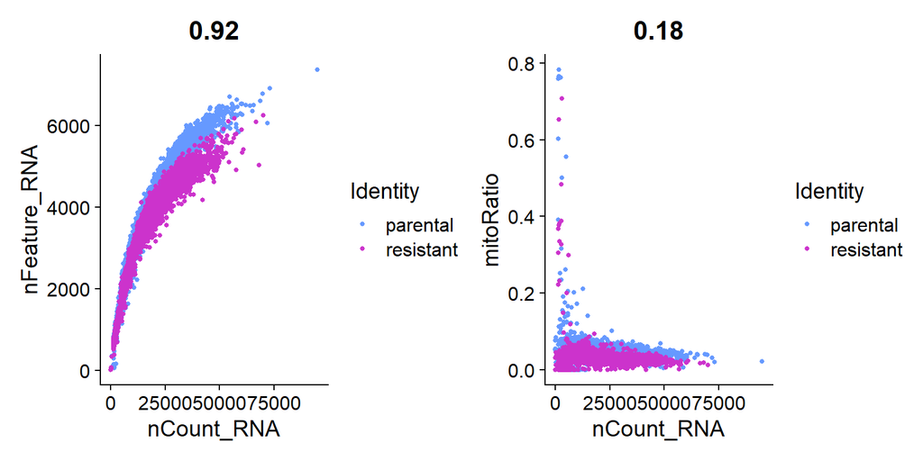

```r
plot1 <- FeatureScatter(GE, feature1 = "nCount_RNA", feature2 = "nFeature_RNA", group.by = "treatment", cols = mycols)
plot2 <- FeatureScatter(GE, feature1 = "nCount_RNA", feature2 = "mitoRatio", group.by = "treatment", cols = mycols)
plot1 + plot2
```

```r
print(paste("Before any filtering, we have", as.character(dim(GE)[2]), "cells."))
```

```
## [1] "Before any filtering, we have 8574 cells."
```

```r
print(paste(sum(GE$treatment=="parental"), "parental cells"))
```

```
## [1] "4452 parental cells"
```

```r
print(paste(sum(GE$treatment=="resistant"), "resistant cells"))
```

```
## [1] "4122 resistant cells"
```

```r
#Cell counts
GE <- subset(GE, subset = nFeature_RNA >= lim)
print(paste("After removing cells with low gene counts, we end up with", as.character(dim(GE)[2]), "cells."))
```

```
## [1] "After removing cells with low gene counts, we end up with 6645 cells."
```

```r
# UMIs
GE <- subset(GE, subset = nCount_RNA>500)
print(paste("After removing cells with low UMI, we end up with", as.character(dim(GE)[2]), "cells."))
```

```
## [1] "After removing cells with low UMI, we end up with 6645 cells."
```

```r
#Mitochondrial filter
GE <- subset(GE, subset = (treatment == "parental" & mitoRatio > upper_limit_par), invert=T)
print(paste("After removing cells with high MT in parental, we end up with", as.character(dim(GE)[2]), "cells."))
```

```
## [1] "After removing cells with high MT in parental, we end up with 6622 cells."
```

```r
GE <- subset(GE, subset = (treatment == "resistant" & mitoRatio > upper_limit_res), invert=T)
print(paste("After removing cells with high MT in resistant, we end up with", as.character(dim(GE)[2]), "cells."))
```

```
## [1] "After removing cells with high MT in resistant, we end up with 6567 cells."
```

```r
#Perplexity
GE <- subset(GE, subset = log10GenesPerUMI > 0.8)
print(paste("After removing cells with low MT complexity, we end up with", as.character(dim(GE)[2]), "cells."))
```

```
## [1] "After removing cells with low MT complexity, we end up with 6414 cells."
```

```r
print(paste("We end up with", as.character(dim(GE)[2]), "cells:"))
```

```
## [1] "We end up with 6414 cells:"
```

```r
print(paste(sum(GE$treatment=="parental"), "parental cells"))
```

```
## [1] "3321 parental cells"
```

```r
print(paste(sum(GE$treatment=="resistant"), "resistant cells."))
```

```
## [1] "3093 resistant cells."
```

The following plot shows the distribution of the metrics **after filtering**:

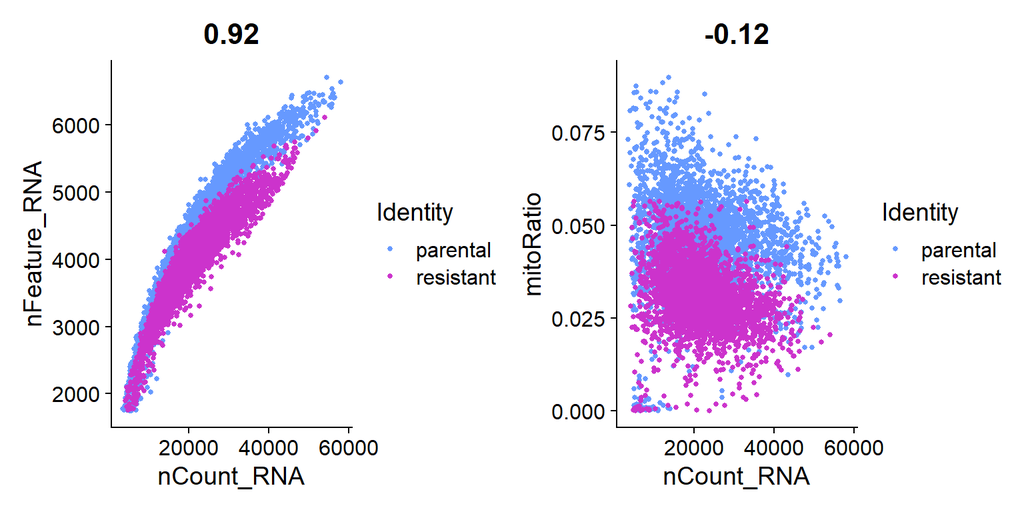

```r
plot1 <- FeatureScatter(GE, feature1 = "nCount_RNA", feature2 = "nFeature_RNA", group.by = "treatment", cols = mycols)
plot2 <- FeatureScatter(GE, feature1 = "nCount_RNA", feature2 = "mitoRatio", group.by = "treatment", cols = mycols)
plot1 + plot2
```

# 3 Filter genes

## 3.1 Motivation

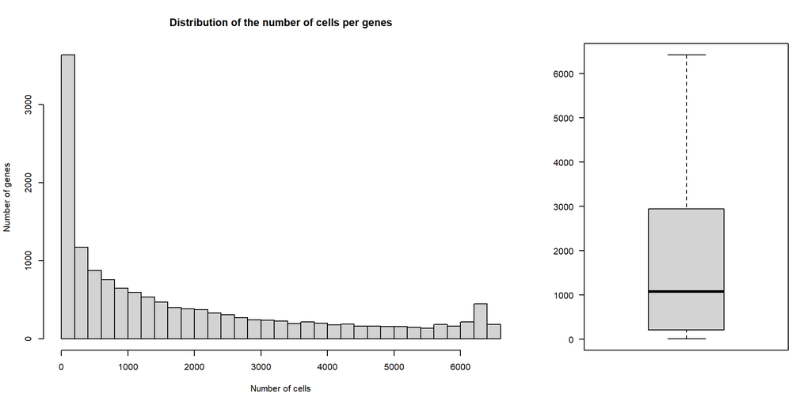

```r
layout(matrix(ncol=3,nrow=1,c(1,1,2),byrow = TRUE))

count_matrix <- GE@assays$RNA@layers$counts
# Convert the count matrix to binary (1 if a gene is expressed in a cell, 0 otherwise)
binary_matrix <- as.matrix(count_matrix > 0)
# Compute the number of cells expressing each gene
cells_per_gene <- Matrix::rowSums(binary_matrix)
# Print the result
hist(cells_per_gene, main="Distribution of the number of cells per genes", ylab="Number of genes", xlab="Number of cells", breaks=30)
boxplot(cells_per_gene,outline=FALSE,las=1)
```

Single-cell data have a very low sensitivity and therefore the data are very sparse with many genes with zero counts. It is common to filter out these genes, similarly to what we previously did with bulk RNA-sequencing data. Obviously genes with zero count across all cells are filtered out. Additionally many studies select genes with read count above a pre-defined threshold for example selecting genes which are expressed in 10 or more cells. However we propose an alternative based on our previous work on bulk. As performed with bulk RNA-sequencing data, where non-reliably expressed genes were filtered out in order to remove non-relevant genes that can add noise to the data, we will apply the same logic here.

## 3.2 Create pseudo-bulk

We first create pseudo-bulk RNA-seq data of dimension $g\times2$ where $g$ is the number of genes across two groups (parental and resistant).

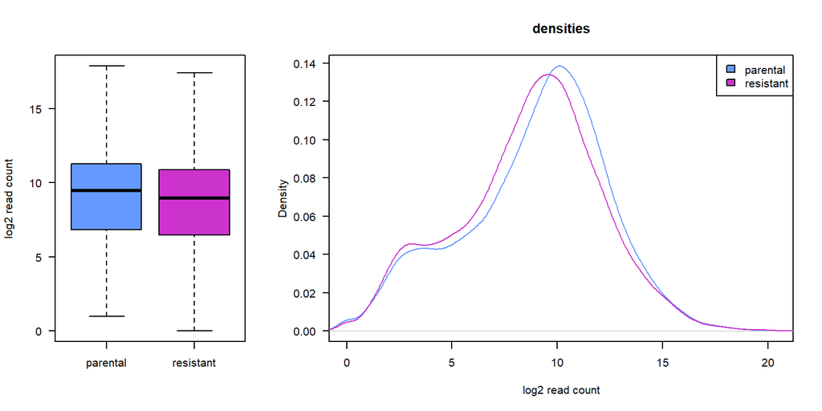

```r
layout(matrix(ncol=3,nrow=1,c(1,2,2),byrow = TRUE))
psbulk_parental  <- log2(rowSums(subset(GE, subset = treatment == "parental")@assays$RNA@layers$counts) + 1)
psbulk_resistant <- log2(rowSums(subset(GE, subset = treatment == "resistant")@assays$RNA@layers$counts) + 1)
boxplot(list(parental=psbulk_parental,resistant=psbulk_resistant),outline=FALSE,col=mycols,las=1,ylab="log2 read count")
multidensity(list(parental=psbulk_parental,resistant=psbulk_resistant),col=mycols,las=1,xlab="log2 read count")
```

## 3.3 Remove genes not reliably expressed at the pseudobulk level – **assignment week 9**

Let’s now fit a bimodal distribution on the pseudo-bulk expression of each sample group. We will find the limits in order to remove 90% of the background.

**Your assignment this week:** - Fit a bimodal distribution on the pseudo-bulk expression of each sample group (parental and resistant) and find the limits to remove 90% of the background. - Plot histograms showing the distribution of parental and resistant pseudo-bulk expression and indicate the limits to remove 90% of the background in red on these plots.

```r
# 1. Fit bimodal distribution
# WRITE YOUR CODE HERE; YOU SHOULD STORE THE LIMITS IN TWO VARIABLES

# Fit bimodal distribution on parental pseudo-bulk expression
fit_parental <- mclust::densityMclust(data = psbulk_parental, G = 2, plot = FALSE)
```

```
## fitting ...
##   |                                                                                                                                                           |                                                                                                                                          …
```

```r
# Find the limits to remove 90% of the background for parental
lim_parental <- qnorm(0.9, mean = fit_parental$parameters$mean[1], sd = sqrt(fit_parental$parameters$variance$sigmasq[1]))

# Fit bimodal distribution on resistant pseudo-bulk expression
fit_resistant <- mclust::densityMclust(data = psbulk_resistant, G = 2, plot = FALSE)
```

```
## fitting ...
##   |                                                                                                                                                           |                                                                                                                                          …
```

```r
# Find the limits to remove 90% of the background for resistant
lim_resistant <- qnorm(0.9, mean = fit_resistant$parameters$mean[1], sd = sqrt(fit_resistant$parameters$variance$sigmasq[1]))

# Print the limits
print(paste("Limit parental:", lim_parental, sep=""))
```

```
## [1] "Limit parental:5.52546517010088"
```

```r
print(paste("Limit resistant:", lim_resistant, sep=""))
```

```
## [1] "Limit resistant:4.77326817227434"
```

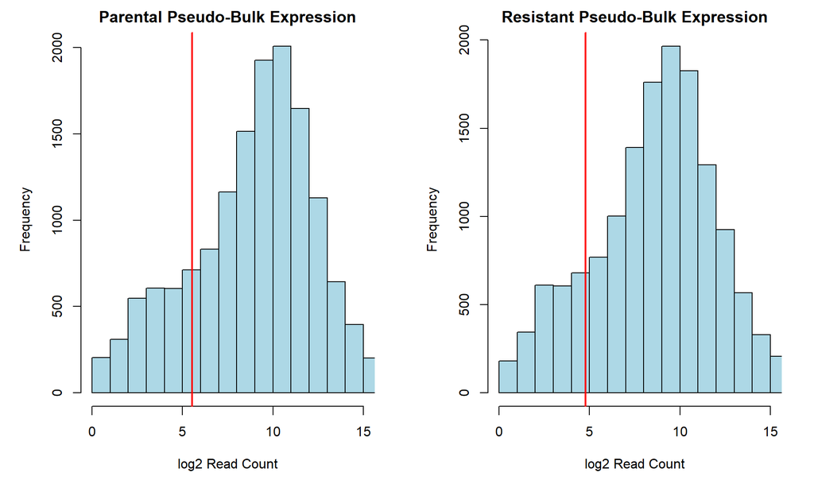

```r
# 2. PLOT HISTOGRAMS OF PARENTAL AND RESISTANT PSEUDO-BULK WITH LIMITS FOUND ABOVE
# WRITE YOUR CODE HERE;
# Plot histograms showing the distribution of parental and resistant pseudo-bulk expression
par(mfrow = c(1, 2), mar = c(5, 5, 2, 2))
hist(psbulk_parental, main = "Parental Pseudo-Bulk Expression", xlab = "log2 Read Count", ylab = "Frequency", col = "lightblue", xlim = c(0, 15))
abline(v = lim_parental, col = "red", lwd = 2)

hist(psbulk_resistant, main = "Resistant Pseudo-Bulk Expression", xlab = "log2 Read Count", ylab = "Frequency", col = "lightblue", xlim = c(0, 15))
abline(v = lim_resistant, col = "red", lwd = 2)
```

```r
# 3. SELECT FOR RELIABLY EXPRESSED - completed
# Filter according to the found thresholds
indexes_parental <- which(psbulk_parental > lim_parental)
indexes_resistant <- which(psbulk_resistant > lim_resistant)

# We keep a gene if reliably expressed in one of the two conditions
GE_filtered <- GE[union(indexes_parental, indexes_resistant), ]

# Recalculate pseudo-bulk expression after filtering
psbulk_parental_filtered <- log2(rowSums(subset(GE_filtered, subset = treatment == "parental")@assays$RNA@layers$counts) + 1)
psbulk_resistant_filtered <- log2(rowSums(subset(GE_filtered, subset = treatment == "resistant")@assays$RNA@layers$counts) + 1)

# Print the number of genes after filtering
print(paste("After the filtering based on pseudo-bulk expression, we have", as.character(dim(GE_filtered)[1]), "genes."))
```

```
## [1] "After the filtering based on pseudo-bulk expression, we have 12517 genes."
```

# 4 Data normalization

The goal of normalization is to account for observed differences in measurements between samples and/or features (e.g., genes) resulting from technical artifacts or unwanted biological effects (e.g., batch effects) rather than biological effects of interest.

Normalization of scRNA-seq data is often accomplished via methods developed for bulk RNA-seq or even microarray data. These methods tend to neglect prominent features of scRNA-seq data such as Cole et al. Cell Systems, 2019:

- zero inflation, i.e., excess of zero read counts observed in some single-cell protocols
- transcriptome-wide nuisance effects (e.g., batch) comparable in magnitude to the biological effects of interest
- uneven sample quality, e.g., in terms of alignment rates and nucleotide composition

Seurat proposes different normalisation methods that will be tested here and compared using the distributions of average gene expression per cell and per gene:

- `LogNormalize`: feature counts for each cell are divided by the total counts for that cell and multiplied by the scale.factor. This is then natural-log transformed using `log1p`.
- `CLR`: Applies a centered log ratio transformation
- `RC`: Relative counts. Feature counts for each cell are divided by the total counts for that cell and multiplied by the scale.factor. No log-transformation is applied. For counts per million (CPM) set scale.factor = 1e6
- `SCTransform`= modeling framework for the normalization and variance stabilization of molecular count data from scRNA-seq experiments. This procedure omits the need for heuristic steps including pseudocount addition or log-transformation and improves common downstream analytical tasks such as variable gene selection, dimensional reduction, and differential expression. please look at the full vignette [here](https://satijalab.org/seurat/articles/sctransform_vignette.html).

We also propose to test with the Quantile Normalisation which has been previously proposed in protocols lacking UMI counts (Townes et al. *Genome Biology (2020)*)[https://link.springer.com/article/10.1186/s13059-020-02078-0].